# ICE Arrests Nationwide: Geographic Distribution

Post-inauguration arrests from the DDP FOIA dataset

Published

September 23, 2026

Notes for next improvements: 1. Include Alaska and Hawaii on the national maps. 2. The county-level data excludes a lot of towns, Louisiana’s parishes, and many metropolitan areas that don’t follow the “NAME COUNTY” pattern. (We should examine the share of arrests in each state that make each of the patterns.) 3. We could create an interactive line graph with all of the state arrest rates.

Maps and tables below cover arrests on or after **January 20, 2025**. **384,475** arrests · **95.2%** have a state recorded. The monthly trend chart shows the full dataset for context.

## State Bubble Map

Circle **area** is proportional to the number of arrests. Circle **color** shows arrests per 1,000 estimated undocumented immigrants (Pew 2023 estimates), a rough intensity measure independent of state size. Popups include Census 2025 total population and per-capita rates.

[interactive chart not shown]

**Top 20 states by arrests:**

| State | Arrests | Arrests/1k undoc. | Undoc. pop. (Pew 2023) | Population (2025) | % of arrests |
| --- | --- | --- | --- | --- | --- |
| Texas | 93279 | 45.50 | 2,050,000 | 31,709,821 | 25.5 |
| Florida | 36182 | 22.61 | 1,600,000 | 23,462,518 | 9.9 |
| California | 32218 | 14.32 | 2,250,000 | 39,355,309 | 8.8 |
| New York | 13682 | 16.58 | 825,000 | 20,002,427 | 3.7 |
| Georgia | 13306 | 29.57 | 450,000 | 11,302,748 | 3.6 |
| Arizona | 11177 | 37.26 | 300,000 | 7,623,818 | 3.1 |
| Virginia | 10761 | 33.11 | 325,000 | 8,880,107 | 2.9 |
| New Jersey | 10621 | 17.70 | 600,000 | 9,548,215 | 2.9 |
| Tennessee | 10280 | 54.11 | 190,000 | 7,315,076 | 2.8 |
| Pennsylvania | 8378 | 27.93 | 300,000 | 13,059,432 | 2.3 |
| Massachusetts | 6847 | 17.12 | 400,000 | 7,154,084 | 1.9 |
| Alabama | 6718 | 79.04 | 85,000 | 5,193,088 | 1.8 |
| Maryland | 6367 | 18.19 | 350,000 | 6,265,347 | 1.7 |
| Oklahoma | 6292 | 62.92 | 100,000 | 4,123,288 | 1.7 |
| Illinois | 6279 | 11.42 | 550,000 | 12,719,141 | 1.7 |
| North Carolina | 6265 | 14.74 | 425,000 | 11,197,968 | 1.7 |
| Louisiana | 6121 | 55.65 | 110,000 | 4,618,189 | 1.7 |
| Minnesota | 5768 | 44.37 | 130,000 | 5,830,405 | 1.6 |
| South Carolina | 5063 | 36.16 | 140,000 | 5,570,274 | 1.4 |
| Utah | 4898 | 34.99 | 140,000 | 3,538,904 | 1.3 |

## County-Level Choropleth

County names are extracted from `apprehension_site_landmark` using a “[NAME] COUNTY” pattern.

> **Coverage:** 26.4% of post-January 20, 2025 arrests mapped to a county.

[interactive chart not shown]

> **Note:** Counties with zero arrests shown in light grey may have arrests recorded under non-specific landmarks. Alaska and Hawaii are excluded from the `maps` package continental US boundary data.

**Top 30 counties by arrests:**

| County | State | N | % |
| --- | --- | --- | --- |
| Dallas | Texas | 13454 | 13.3 |
| Los Angeles | California | 5933 | 5.8 |
| Miami Dade | Florida | 2700 | 2.7 |
| Harris | Texas | 2456 | 2.4 |
| Denver | Colorado | 2310 | 2.3 |
| Cap - Maricopa | Arizona | 1943 | 1.9 |
| Charleston | South Carolina | 1589 | 1.6 |
| Mecklenburg | North Carolina | 1353 | 1.3 |
| Tam-Hillsborough | Florida | 1101 | 1.1 |
| Broward | Florida | 1062 | 1.0 |
| Clark | Nevada | 972 | 1.0 |
| Erie | New York | 970 | 1.0 |
| Collier | Florida | 878 | 0.9 |
| Tam-Polk | Florida | 782 | 0.8 |
| Ftm-Lee | Florida | 748 | 0.7 |
| Marion | Indiana | 746 | 0.7 |
| Prince George’s | Maryland | 735 | 0.7 |
| Travis | Texas | 666 | 0.7 |
| Jac - St John | Florida | 634 | 0.6 |
| Davidson | Tennessee | 629 | 0.6 |
| Utah | Utah | 601 | 0.6 |
| Montgomery | Maryland | 586 | 0.6 |
| Bexar | Texas | 579 | 0.6 |
| Tam-Pinellas | Florida | 573 | 0.6 |
| Stuart-Martin | Florida | 567 | 0.6 |
| Orl - Orange | Florida | 485 | 0.5 |
| Hidalgo | Texas | 469 | 0.5 |
| Rutherford | Tennessee | 447 | 0.4 |
| El Paso | Colorado | 443 | 0.4 |
| Val Verde | Texas | 440 | 0.4 |

## Monthly Trends by Top State

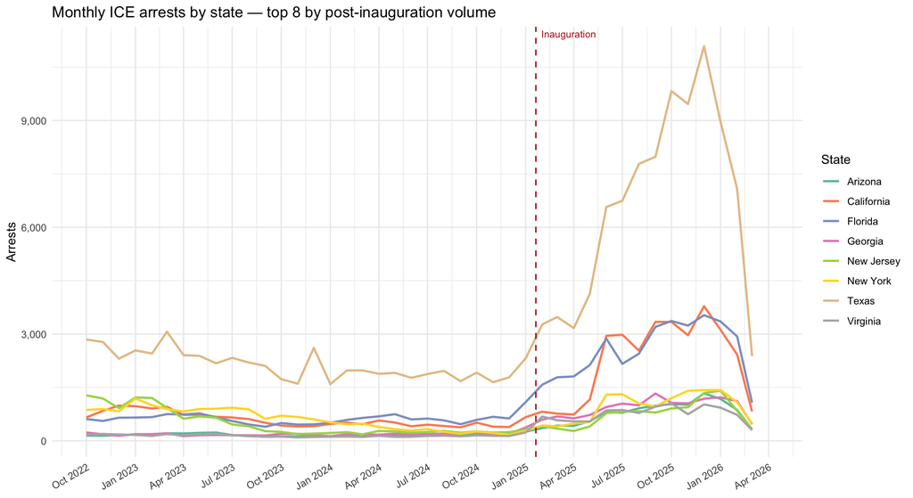

## Arrest Rate Change by State

For each state, compute arrests **per day** in the before and after periods, then take the ratio. Values above 1 mean more arrests per day after inauguration; values below 1 mean fewer. Only states with at least 30 arrests in the before period are included.

**All states and DC — arrest rate change and removal outcomes:**

| Per day (before) | Per day (after) | Ratio | State | Arrests (after) | Arrests/1k undoc. | Undoc. pop. (Pew) | % Removed | % Released | % Pending |
| --- | --- | --- | --- | --- | --- | --- | --- | --- | --- |
| 0.06 | 3.82 | 63.05 | District Of Columbia | 1665 | 47.57 | 35000 | NaN | NaN | NaN |
| 0.43 | 9.91 | 23.05 | New Mexico | 4320 | 72 | 60000 | NaN | NaN | NaN |
| 0.39 | 4.46 | 11.31 | Oregon | 1944 | 16.2 | 120000 | NaN | NaN | NaN |
| 0.65 | 4.89 | 7.5 | West Virginia | 2131 | 213.1 | 10000 | NaN | NaN | NaN |
| 0.39 | 2.91 | 7.4 | Idaho | 1268 | 31.7 | 40000 | NaN | NaN | NaN |
| 0.2 | 1.38 | 7.02 | South Dakota | 603 | 60.3 | 10000 | NaN | NaN | NaN |
| 4.7 | 24.68 | 5.25 | Virginia | 10761 | 33.11 | 325000 | NaN | NaN | NaN |
| 0.45 | 2.34 | 5.19 | Wyoming | 1022 | 102.2 | 10000 | NaN | NaN | NaN |
| 0.14 | 0.71 | 5.13 | Hawaii | 308 | 7.7 | 40000 | NaN | NaN | NaN |
| 6 | 30.52 | 5.09 | Georgia | 13306 | 29.57 | 450000 | NaN | NaN | NaN |

[output cut: 41 more lines]

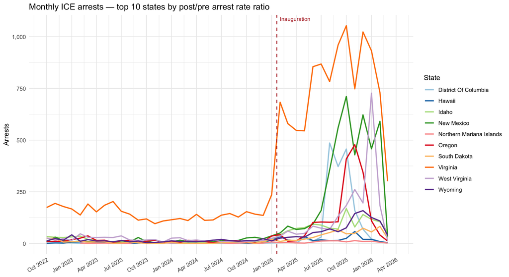

## Removal Destinations

`departure_country` records where each person was actually sent. Of **308,163** removals with a recorded destination, **12,553** (4.1%) involved removal to a country other than the person’s citizenship country. The grid below shows nationalities and destinations with at least 500 removals.

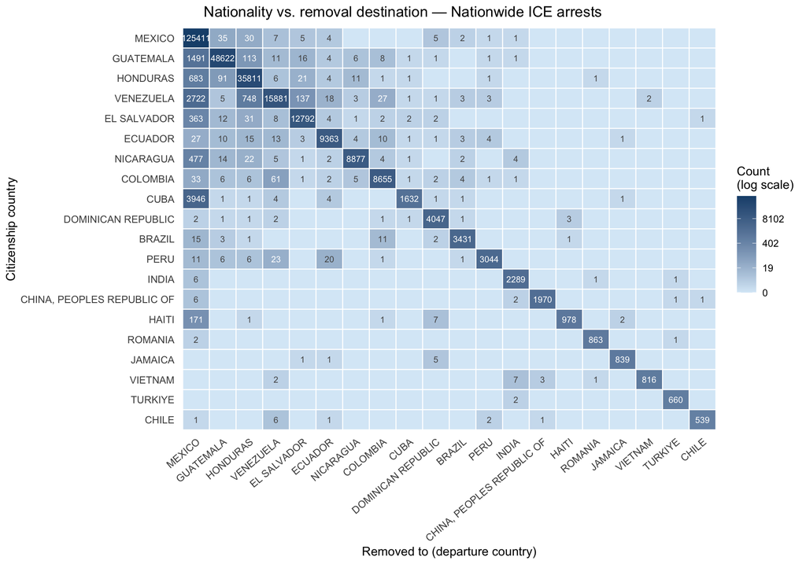